**DSP for Rotating Machinery**

By Prof. Seungchul Lee  
http://iai.postech.ac.kr/  
Industrial AI Lab at POSTECH

Table of Contents

# 1. Data from Our Testbed

- unbalance.mat $\implies$ [01 02 03 04]
  - 01 = 시간
  - 02 = 불균형이 거의 없는 경우 진동 (정상)
  - 03 = 불균형이 있는 경우 진동 (1X성분이 증가) 3.6g * 44.4mm
  - 04 = 불균형이 더 심한 경우 진동 (1X성분이 매우 증가) 5.6g * 44.4mm :

```python
import numpy as np
import matplotlib.pyplot as plt
%matplotlib inline

from scipy import signal
from scipy.fftpack import fft, ifft, fftshift
from scipy import stats

import scipy.io
```

```python
filename = './data_files/unbalance.mat'
data = scipy.io.loadmat(filename)
```

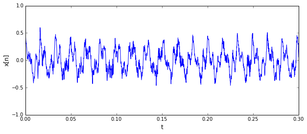

```python
time = data['unbalance'][:,0]
x = data['unbalance'][:,3]

plt.figure(figsize=(10, 4))
plt.plot(time, x)
plt.xlim([0, 0.3])
plt.ylim([-1, 1])
plt.xlabel('t', fontsize=12)
plt.ylabel('x[n]', fontsize=12)
plt.show()
```

# 2. Feature Extraction

## 2.1. Feature Extraction from Time Domain

**Moments of a signal: mean, variance, skewness, and kurtosis**

- mean

$$\bar x = \frac{1}{N} \sum_{n=1}^{N} x[n]$$

- variance

$$\text{var} (x) = \frac{1}{N-1} \sum_{n=1}^{N} (x[n] - \bar x)^2$$$$\sigma = \sqrt{\text{var}}$$

- Note: RMS (root mean square)

$$\text{RMS} = \sqrt{\frac{1}{N} \sum_{n=1}^{N}x[n]^2 } = \sqrt{\bar x ^2 + \sigma^2}$$

[figure not shown]

- Skewness
  - a positive value of skewness signifies a distribution with an asymmetric tail extending out towards more positive $x$
  - a negative value signifies a distribution whose tail extends out towards more negative $x$

$$\text{skewness} (x) = \frac{1}{N} \sum_{n=1}^{N} \left(\frac{x[n] - \bar x}{\sigma} \right)^3$$

- Kurtosis
  - It measures the relative peakedness or flatness of a distribution. Relative to what? A normal distribution

$$\text{kurtosis} (x) = \frac{1}{N} \sum_{n=1}^{N} \left(\frac{x[n] - \bar x}{\sigma} \right)^4 - 3$$

$\qquad \quad$where the $−3$ term makes the value zero for a normal distribution.

```python
# mean
print(np.mean(x))

# variance
print(np.var(x))

# rms
print(np.sqrt(np.mean(x**2)))

# skewness
print(stats.skew(x))

# kurtosis
print(stats.kurtosis(x))
```

```
0.000226650590002
0.0403172240872
0.200791621981
0.16905197562643445
-0.6241039483251325
```

**Waveform related features**

- Crest factor

$$\frac{x_{\max}}{x_{\text{rms}}}$$

- Impulse factor

$$\frac{x_{\max}}{x_{\text{mean}}}$$

- Shape factor

$$\frac{x_{\text{rms}}}{x_{\text{mean}}}$$

```python
# crest factor
print(np.max(x)/(np.sqrt(np.mean(x**2))))

# impulse factor
print(np.max(x)/np.mean(x))

# shape factor
print((np.sqrt(np.mean(x**2)))/np.mean(x))
```

```
3.02293516997
2678.043132
885.908225426
```

## 2.2. Feature Extraction from Frequency Domain

Amplitudes at the specific frequencies

- Harmonics/subharmonics ($1X,\;2X,\;3X, \cdots$)
- BPFI (ball pass frequency inner race)

$$\text{BPFI} = \frac{N}{2} \times F \times \left( 1 + \frac{B}{P} \cos \theta \right)$$

- BPFO (ball pass frequency outer race)

$$\text{BPFO} = \frac{N}{2} \times F \times \left( 1 - \frac{B}{P} \cos \theta \right)$$

- BSF (ball spin frequency)

$$\text{BSF} = \frac{P}{2B} \times F \times \left[ 1 - \left( \frac{B}{P} \cos \theta \right)^2 \right]$$

- BDF (ball defect frequency)

$$\text{BDF} = 2 \times \text{BSF} = \frac{P}{B} \times F \times \left[ 1 - \left( \frac{B}{P} \cos \theta \right)^2 \right]$$

```python
T = time[1] - time[0]
Fs = 1/T

N = len(time)
L = N/Fs
t = np.arange(0, time[-1], T)
```

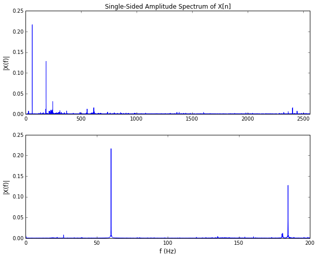

```python
# single-sided fft

xt = fft(x)/N
xtss = xt[0:int(N/2)+1]
xtss[1:-1] = 2*xtss[1:-1]

k = np.arange(0, N)
f = (Fs/N)*k
fss = f[0:int(N/2)+1]

# plot
plt.figure(figsize=(10,8))
plt.subplot(2,1,1)
plt.plot(fss, np.abs(xtss))
plt.ylabel('|X(f)|', fontsize=12)
plt.xlim([np.min(fss), np.max(fss)])
plt.title('Single-Sided Amplitude Spectrum of X[n]', fontsize=12)

plt.subplot(2,1,2)
plt.plot(fss, np.abs(xtss))
plt.xlim([0, 200])
plt.xlabel('f (Hz)', fontsize=12)
plt.ylabel('|X(f)|', fontsize=12)
plt.show()
```

$$X_{\text{feature vector}} = \text{amplitude at the specific frequency}$$

```python
amplitude = np.abs(xtss)

BPFO = 183.183
c = 20

filter01 = np.zeros([1, len(fss)])
filter01[0, int(N/Fs*(BPFO-c)):int(N/Fs*(BPFO+c))] = 1

X1 = np.max(amplitude*filter01)
X1
```

```
0.12777725762707193
```

# 3. Fault Modes

- unbalance.mat $\implies$ [01 02 03 04]
  - 01 = 시간
  - 02 = 불균형이 거의 없는 경우 진동 (정상)
  - 03 = 불균형이 있는 경우 진동 (1X성분이 증가) 3.6g * 44.4mm
  - 04 = 불균형이 더 심한 경우 진동 (1X성분이 매우 증가) 5.6g * 44.4mm :
- misalign.mat $\implies$ [01 02 03]
  - 01 = 시간
  - 02 = 불균형이 있는 경우 (1X성분이 증가) 3.6g * 44.4mm
  - 03 = 불균형이 있으면서, 정렬불량이 심한 경우 (2X 성분이 크게 증가) - 2mm 정렬불량
- outerrace_fault $\implies$ [01 02 03 04]
  - 01 = 시간
  - 02 = 불균형이 있는 경우 (1X성분이 증가) 3.6g * 44.4mm
  - 03 = 불균형이 있으면서, 외륜결함이 있는 경우
  - 04 = 불균형이 있으면서, 외륜결함으로 구동 중 베어링이 파손된 경우
- innerace_fault $\implies$ [01 02 03 04]
  - 01 = 시간
  - 02 = 불균형이 있는 경우 (1X성분이 증가) 3.6g * 44.4mm
  - 03 = 불균형이 있으면서, 내륜결함이 있는 경우
  - 04 = 불균형이 있으면서, 내륜결함으로 구동 중 베어링이 파손된 경우

## 3.1. Unbalance

- unbalance.mat $\implies$ [01 02 03 04]
  - 01 = 시간
  - 02 = 불균형이 거의 없는 경우 진동 (정상)
  - 03 = 불균형이 있는 경우 진동 (1X성분이 증가) 3.6g * 44.4mm
  - 04 = 불균형이 더 심한 경우 진동 (1X성분이 매우 증가) 5.6g * 44.4mm :

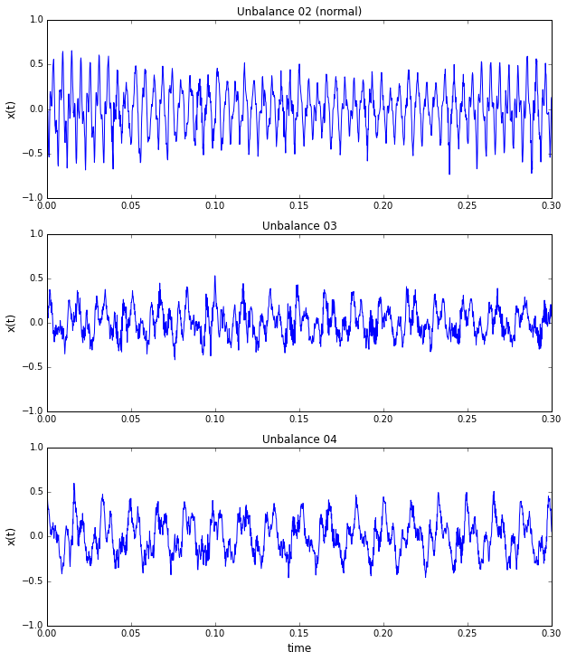

```python
filename = './data_files/unbalance.mat'
data = scipy.io.loadmat(filename)

time = data['unbalance'][:,0]
unbal02 = data['unbalance'][:,1]
unbal03 = data['unbalance'][:,2]
unbal04 = data['unbalance'][:,3]

plt.figure(figsize=(10,12))
plt.subplot(3,1,1)
plt.plot(time, unbal02)
plt.ylabel('x(t)', fontsize=12)
plt.xlim([0, 0.3])
plt.ylim([-1, 1])
plt.title('Unbalance 02 (normal)', fontsize=12)

plt.subplot(3,1,2)
plt.plot(time,unbal03)
plt.xlim([0, 0.3])
plt.ylim([-1, 1])
plt.ylabel('x(t)', fontsize=12)
plt.title('Unbalance 03', fontsize=12)

plt.subplot(3,1,3)
plt.plot(time,unbal04)
plt.xlim([0, 0.3])
plt.ylim([-1, 1])
plt.xlabel('time', fontsize=12)
plt.ylabel('x(t)', fontsize=12)
plt.title('Unbalance 04', fontsize=12)
plt.show()
```

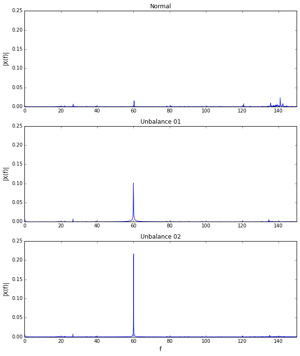

```python
T = time[1] - time[0]
Fs = 1/T

N = len(time)
L = N/Fs
t = np.arange(0, time[-1], T)

# single-sided fft
ut2 = fft(unbal02)/N
ut2ss = ut2[0:int(N/2)+1]
ut2ss[1:-1] = 2*ut2ss[1:-1]

ut3 = fft(unbal03)/N
ut3ss = ut3[0:int(N/2)+1]
ut3ss[1:-1] = 2*ut3ss[1:-1]

ut4 = fft(unbal04)/N
ut4ss = ut4[0:int(N/2)+1]
ut4ss[1:-1] = 2*ut4ss[1:-1]

k = np.arange(0, N)
f = (Fs/N)*k
fss = f[0:int(N/2)+1]

# plot
plt.figure(figsize=(10,12))
plt.subplot(3,1,1)
plt.plot(fss, np.abs(ut2ss))
plt.ylabel('|X(f)|', fontsize=12)
plt.xlim([0, 150])
plt.ylim([0, 0.25])
plt.title('Normal', fontsize=12)

plt.subplot(3,1,2)
plt.plot(fss, np.abs(ut3ss))
plt.xlim([0, 150])
plt.ylim([0, 0.25])
plt.ylabel('|X(f)|', fontsize=12)
plt.title('Unbalance 01', fontsize=12)

plt.subplot(3,1,3)
plt.plot(fss, np.abs(ut4ss))
plt.xlim([0, 150])
plt.ylim([0, 0.25])
plt.xlabel('f', fontsize=12)
plt.ylabel('|X(f)|', fontsize=12)
plt.title('Unbalance 02', fontsize=12)
plt.show()
```

## 3.2. Misalignment

- misalign.mat $\implies$ [01 02 03]
  - 01 = 시간
  - 02 = 불균형이 있는 경우 (1X성분이 증가) 3.6g * 44.4mm
  - 03 = 불균형이 있으면서, 정렬불량이 심한 경우 (2X 성분이 크게 증가) - 2mm 정렬불량

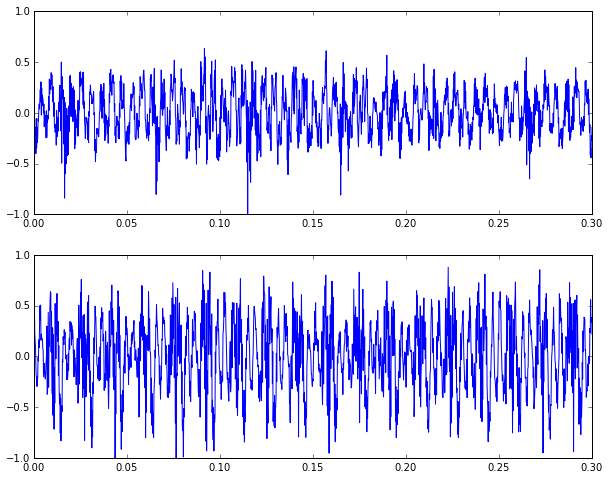

```python
filename = './data_files/misalign.mat'
data = scipy.io.loadmat(filename)

time = data['misalign'][:,0]
misalign02 = data['misalign'][:,1]
misalign03 = data['misalign'][:,2]

plt.figure(figsize=(10,8))
plt.subplot(2,1,1)
plt.plot(time, misalign02)
plt.xlim([0, 0.3])
plt.ylim([-1, 1])

plt.subplot(2,1,2)
plt.plot(time, misalign03)
plt.xlim([0, 0.3])
plt.ylim([-1, 1])
plt.show()
```

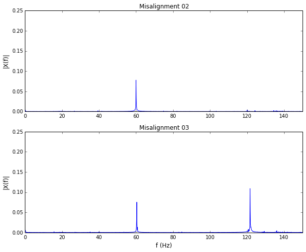

```python
T = time[1] - time[0]
Fs = 1/T

N = len(time)
L = N/Fs
t = np.arange(0, time[-1], T)

# single-sided fft
mt2 = fft(misalign02)/N
mt2ss = mt2[0:int(N/2)+1]
mt2ss[1:-1] = 2*mt2ss[1:-1]

mt3 = fft(misalign03)/N
mt3ss = mt3[0:int(N/2)+1]
mt3ss[1:-1] = 2*mt3ss[1:-1]

k = np.arange(0, N)
f = (Fs/N)*k
fss = f[0:int(N/2)+1]

# plot
plt.figure(figsize=(10,8))
plt.subplot(2,1,1)
plt.plot(fss, np.abs(mt2ss))
plt.ylabel('|X(f)|', fontsize=12)
plt.xlim([0, 150])
plt.ylim([0, 0.25])
plt.title('Misalignment 02', fontsize=12)

plt.subplot(2,1,2)
plt.plot(fss, np.abs(mt3ss))
plt.xlim([0, 150])
plt.ylim([0, 0.25])
plt.xlabel('f (Hz)', fontsize=12)
plt.ylabel('|X(f)|', fontsize=12)
plt.title('Misalignment 03', fontsize=12)
plt.show()
```

## 3.3. Outer Race

- outerrace_fault $\implies$ [01 02 03 04]
  - 01 = 시간
  - 02 = 불균형이 있는 경우 (1X성분이 증가) 3.6g * 44.4mm
  - 03 = 불균형이 있으면서, 외륜결함이 있는 경우
  - 04 = 불균형이 있으면서, 외륜결함으로 구동 중 베어링이 파손된 경우

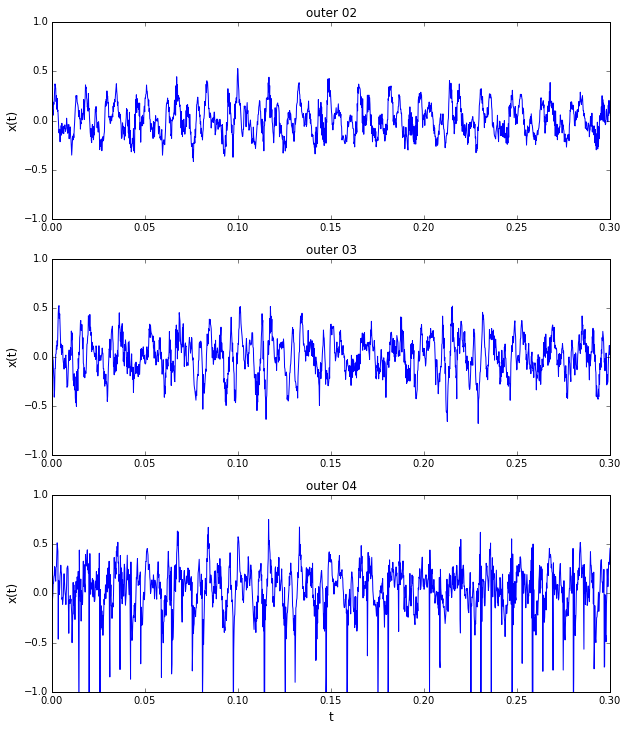

```python
filename = './data_files/outerrace_fault.mat'
data = scipy.io.loadmat(filename)

time = data['outer'][:,0]
out02 = data['outer'][:,1]
out03 = data['outer'][:,2]
out04 = data['outer'][:,3]

plt.figure(figsize=(10,12))
plt.subplot(3,1,1)
plt.plot(time, out02)
plt.ylabel('x(t)', fontsize=12)
plt.xlim([0, 0.3])
plt.ylim([-1, 1])
plt.title('outer 02', fontsize=12)

plt.subplot(3,1,2)
plt.plot(time, out03)
plt.xlim([0, 0.3])
plt.ylim([-1, 1])
plt.ylabel('x(t)', fontsize=12)
plt.title('outer 03', fontsize=12)

plt.subplot(3,1,3)
plt.plot(time, out04)
plt.xlim([0, 0.3])
plt.ylim([-1, 1])
plt.xlabel('t', fontsize=12)
plt.ylabel('x(t)', fontsize=12)
plt.title('outer 04', fontsize=12)
plt.show()
```

```python
T = time[1] - time[0]
Fs = 1/T

N = len(time)
L = N/Fs
t = np.arange(0, time[-1], T)

# single-sided fft
ot2 = fft(out02)/N
ot2ss = ot2[0:int(N/2)+1]
ot2ss[1:-1] = 2*ot2ss[1:-1]

ot3 = fft(out03)/N
ot3ss = ot3[0:int(N/2)+1]
ot3ss[1:-1] = 2*ot3ss[1:-1]

ot4 = fft(out04)/N
ot4ss = ot4[0:int(N/2)+1]
ot4ss[1:-1] = 2*ot4ss[1:-1]

k = np.arange(0, N)
f = (Fs/N)*k
fss = f[0:int(N/2)+1]
```

```python
BSF = 119.621
BPFO = 183.183
BDF = 239.242
BPFI = 296.817
```

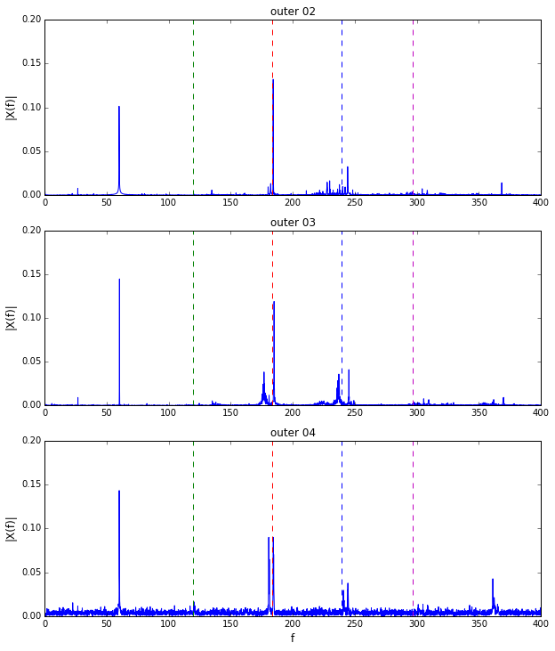

```python
plt.figure(figsize=(10,12))
plt.subplot(3,1,1)
plt.plot(fss, np.abs(ot2ss))
plt.plot([BSF,BSF],[0,0.2], 'g--')
plt.plot([BPFO,BPFO],[0,0.2], 'r--')
plt.plot([BDF,BDF],[0,0.2], 'b--')
plt.plot([BPFI,BPFI],[0,0.2], 'm--')
plt.ylabel('|X(f)|', fontsize=12)
plt.xlim([0, 400])
plt.ylim([0, 0.2])
plt.title('outer 02', fontsize=12)

plt.subplot(3,1,2)
plt.plot(fss, np.abs(ot3ss))
plt.plot([BSF,BSF],[0,0.2], 'g--')
plt.plot([BPFO,BPFO],[0,0.2], 'r--')
plt.plot([BDF,BDF],[0,0.2], 'b--')
plt.plot([BPFI,BPFI],[0,0.2], 'm--')
plt.xlim([0, 400])
plt.ylim([0, 0.2])
plt.ylabel('|X(f)|', fontsize=12)
plt.title('outer 03', fontsize=12)

plt.subplot(3,1,3)
plt.plot(fss, np.abs(ot4ss))
plt.plot([BSF,BSF],[0,0.2], 'g--')
plt.plot([BPFO,BPFO],[0,0.2], 'r--')
plt.plot([BDF,BDF],[0,0.2], 'b--')
plt.plot([BPFI,BPFI],[0,0.2], 'm--')
plt.xlim([0, 400])
plt.ylim([0, 0.2])
plt.xlabel('f', fontsize=12)
plt.ylabel('|X(f)|', fontsize=12)
plt.title('outer 04', fontsize=12)
plt.show()
```

```python
# smoothing using moving average (MA) model

windowsize = 5
b = np.ones([1, windowsize])/windowsize
b = np.reshape(b, [-1,])
a = 1

out02ma = signal.lfilter(b,a,out02)
out02mar = out02 - out02ma # use residual

out03ma = signal.lfilter(b,a,out03)
out03mar = out03 - out03ma

out04ma = signal.lfilter(b,a,out04)
out04mar = out04 - out04ma
```

```python
# envelope analysis

out02mare = np.abs(signal.hilbert(out02mar))
out03mare = np.abs(signal.hilbert(out03mar))
out04mare = np.abs(signal.hilbert(out04mar))

out02marez = out02mare - np.mean(out02mare) # remove dc offset
out03marez = out03mare - np.mean(out03mare)
out04marez = out04mare - np.mean(out04mare)
```

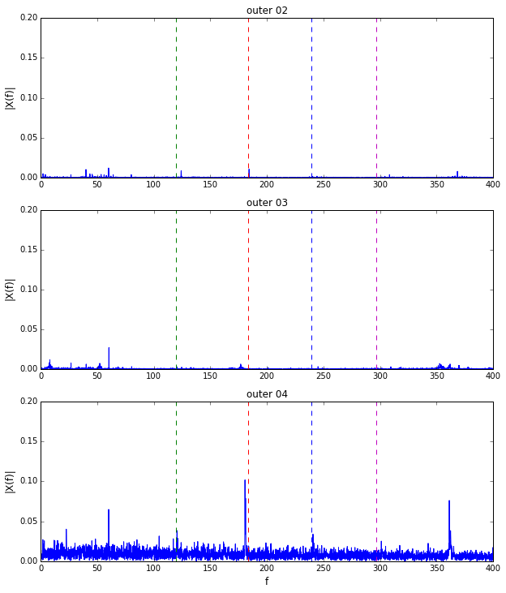

```python
T = time[1] - time[0]
Fs = 1/T

N = len(time)
L = N/Fs
t = np.arange(0, time[-1], T)

# single-sided fft
oet2 = fft(out02marez)/N
oet2ss = oet2[0:int(N/2)+1]
oet2ss[1:-1] = 2*oet2ss[1:-1]

oet3 = fft(out03marez)/N
oet3ss = oet3[0:int(N/2)+1]
oet3ss[1:-1] = 2*oet3ss[1:-1]

oet4 = fft(out04marez)/N
oet4ss = oet4[0:int(N/2)+1]
oet4ss[1:-1] = 2*oet4ss[1:-1]

k = np.arange(0, N)
f = (Fs/N)*k
fss = f[0:int(N/2)+1]

plt.figure(figsize=(10,12))
plt.subplot(3,1,1)
plt.plot(fss, np.abs(oet2ss))
plt.plot([BSF,BSF],[0,0.2], 'g--')
plt.plot([BPFO,BPFO],[0,0.2], 'r--')
plt.plot([BDF,BDF],[0,0.2], 'b--')
plt.plot([BPFI,BPFI],[0,0.2], 'm--')
plt.ylabel('|X(f)|', fontsize=12)
plt.xlim([0, 400])
plt.ylim([0, 0.2])
plt.title('outer 02', fontsize=12)

plt.subplot(3,1,2)
plt.plot(fss, np.abs(oet3ss))
plt.plot([BSF,BSF],[0,0.2], 'g--')
plt.plot([BPFO,BPFO],[0,0.2], 'r--')
plt.plot([BDF,BDF],[0,0.2], 'b--')
plt.plot([BPFI,BPFI],[0,0.2], 'm--')
plt.xlim([0, 400])
plt.ylim([0, 0.2])
plt.ylabel('|X(f)|', fontsize=12)
plt.title('outer 03', fontsize=12)

plt.subplot(3,1,3)
plt.plot(fss, np.abs(oet4ss))
plt.plot([BSF,BSF],[0,0.2], 'g--')
plt.plot([BPFO,BPFO],[0,0.2], 'r--')
plt.plot([BDF,BDF],[0,0.2], 'b--')
plt.plot([BPFI,BPFI],[0,0.2], 'm--')
plt.xlim([0, 400])
plt.ylim([0, 0.2])
plt.xlabel('f', fontsize=12)
plt.ylabel('|X(f)|', fontsize=12)
plt.title('outer 04', fontsize=12)
plt.show()
```

## 3.4. Inner Race

- innerace_fault $\implies$ [01 02 03 04]
  - 01 = 시간
  - 02 = 불균형이 있는 경우 (1X성분이 증가) 3.6g * 44.4mm
  - 03 = 불균형이 있으면서, 내륜결함이 있는 경우
  - 04 = 불균형이 있으면서, 내륜결함으로 구동 중 베어링이 파손된 경우

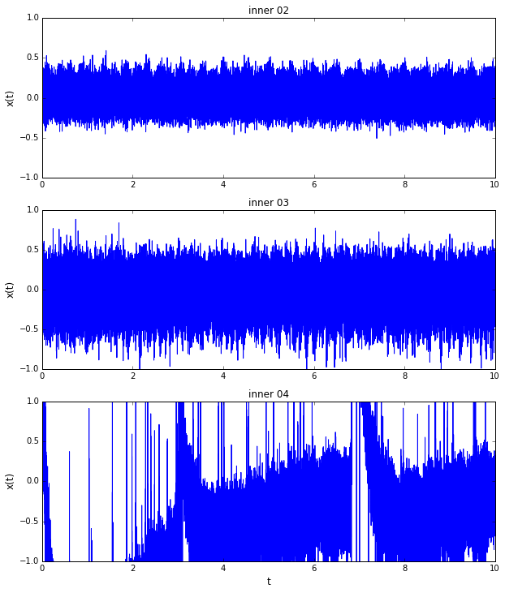

```python
filename = './data_files/innerrace_fault.mat'
data = scipy.io.loadmat(filename)

time = data['inner'][:,0]
in02 = data['inner'][:,1]
in03 = data['inner'][:,2]
in04 = data['inner'][:,3]

plt.figure(figsize=(10,12))
plt.subplot(3,1,1)
plt.plot(time, in02)
plt.ylabel('x(t)', fontsize=12)
plt.xlim([0, 10])
plt.ylim([-1, 1])
plt.title('inner 02', fontsize=12)

plt.subplot(3,1,2)
plt.plot(time, in03)
plt.xlim([0, 10])
plt.ylim([-1, 1])
plt.ylabel('x(t)', fontsize=12)
plt.title('inner 03', fontsize=12)

plt.subplot(3,1,3)
plt.plot(time, in04)
plt.xlim([0, 10])
plt.ylim([-1, 1])
plt.xlabel('t', fontsize=12)
plt.ylabel('x(t)', fontsize=12)
plt.title('inner 04', fontsize=12)
plt.show()
```

```python
# smoothing using moving average (MA) model

windowsize = 5
b = np.ones([1, windowsize])/windowsize
b = np.reshape(b, [-1,])
a = 1

in02ma = signal.lfilter(b,a,in02)
in02mar = in02 - in02ma # use residual

in03ma = signal.lfilter(b,a,in03)
in03mar = in03 - in03ma

in04ma = signal.lfilter(b,a,in04)
in04mar = in04 - in04ma
```

```python
# envelope analysis

in02mare = np.abs(signal.hilbert(in02mar))
in03mare = np.abs(signal.hilbert(in03mar))
in04mare = np.abs(signal.hilbert(in04mar))

in02marez = in02mare - np.mean(in02mare) # remove dc offset
in03marez = in03mare - np.mean(in03mare)
in04marez = in04mare - np.mean(in04mare)
```

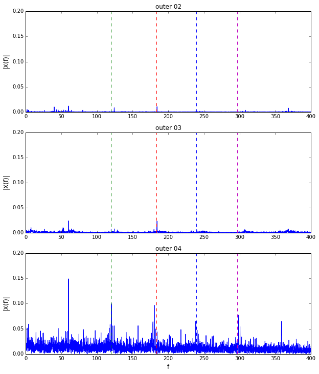

```python
T = time[1] - time[0]
Fs = 1/T

N = len(time)
L = N/Fs
t = np.arange(0, time[-1], T)

# single-sided fft
iet2 = fft(in02marez)/N
iet2ss = iet2[0:int(N/2)+1]
iet2ss[1:-1] = 2*iet2ss[1:-1]

iet3 = fft(in03marez)/N
iet3ss = iet3[0:int(N/2)+1]
iet3ss[1:-1] = 2*iet3ss[1:-1]

iet4 = fft(in04marez)/N
iet4ss = iet4[0:int(N/2)+1]
iet4ss[1:-1] = 2*iet4ss[1:-1]

k = np.arange(0, N)
f = (Fs/N)*k
fss = f[0:int(N/2)+1]

plt.figure(figsize=(10,12))
plt.subplot(3,1,1)
plt.plot(fss, np.abs(iet2ss))
plt.plot([BSF,BSF],[0,0.2], 'g--')
plt.plot([BPFO,BPFO],[0,0.2], 'r--')
plt.plot([BDF,BDF],[0,0.2], 'b--')
plt.plot([BPFI,BPFI],[0,0.2], 'm--')
plt.ylabel('|X(f)|', fontsize=12)
plt.xlim([0, 400])
plt.ylim([0, 0.2])
plt.title('outer 02', fontsize=12)

plt.subplot(3,1,2)
plt.plot(fss, np.abs(iet3ss))
plt.plot([BSF,BSF],[0,0.2], 'g--')
plt.plot([BPFO,BPFO],[0,0.2], 'r--')
plt.plot([BDF,BDF],[0,0.2], 'b--')
plt.plot([BPFI,BPFI],[0,0.2], 'm--')
plt.xlim([0, 400])
plt.ylim([0, 0.2])
plt.ylabel('|X(f)|', fontsize=12)
plt.title('outer 03', fontsize=12)

plt.subplot(3,1,3)
plt.plot(fss, np.abs(iet4ss))
plt.plot([BSF,BSF],[0,0.2], 'g--')
plt.plot([BPFO,BPFO],[0,0.2], 'r--')
plt.plot([BDF,BDF],[0,0.2], 'b--')
plt.plot([BPFI,BPFI],[0,0.2], 'm--')
plt.xlim([0, 400])
plt.ylim([0, 0.2])
plt.xlabel('f', fontsize=12)
plt.ylabel('|X(f)|', fontsize=12)
plt.title('outer 04', fontsize=12)
plt.show()
```

```python
%%javascript
$.getScript('https://kmahelona.github.io/ipython_notebook_goodies/ipython_notebook_toc.js')
```